# Biological QA (mod’ed from Charlotte Soneson’s)

Nicolas Delhomme, mod’ed from Charlotte Soneson’s

2021-03-04

# 1 Setup

Here we load the needed libraries we will need for the analysis and set some graphical parameters. * Libraries

```r
suppressPackageStartupMessages({
  library(DESeq2)
  library(edgeR)
  library(here)
  library(pheatmap)
  library(RColorBrewer)
  library(VennDiagram)
})
```

- Helpers

```r
source(here("R/volcanoPlot.R"))
```

- Graphics

```r
pal <- brewer.pal(8,"Dark2")
```

- Load the data

```r
load(here("data/DE/differentialExpressionObjects.rda"))
```

# 2 Differential expression analysis

## 2.1 Performing differential expression testing with DESeq2

As we have already specified an experimental design when we created the *DESeqDataSet*, we can run the differential expression pipeline on the raw counts with a single call to the function `DESeq`. We can also plot the estimated dispersions. Very easy, just one command

```r
ds_se <- DESeq2::DESeq(ds_se)
```

```
## using 'avgTxLength' from assays(dds), correcting for library size
```

Here, we plot the dispersion estimation to ensure that the assumption that most genes are not differentially expressed holds

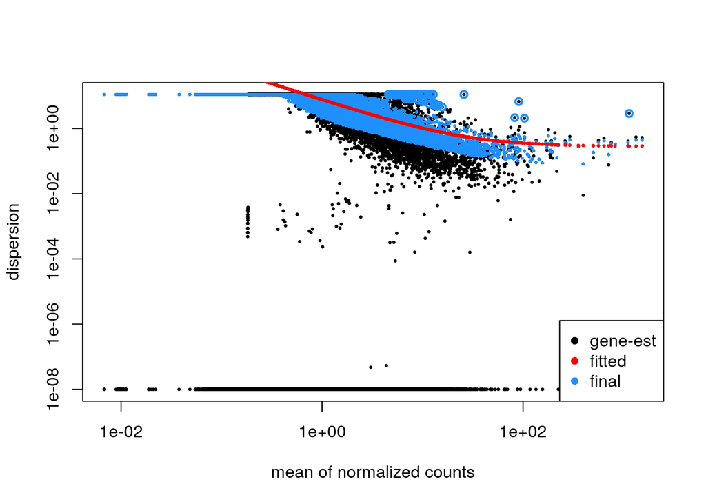

```r
DESeq2::plotDispEsts(ds_se)
```

This function will print out a message for the various steps it performs. These are described in more detail in the manual page for `DESeq`, which can be accessed by typing `?DESeq`. Briefly these are: the estimation of size factors (controlling for differences in the sequencing depth of the samples), the estimation of dispersion values for each gene, and fitting a generalized linear model.

A DESeqDataSet is returned that contains all the fitted parameters within it, and the following section describes how to extract out results tables of interest from this object.

But wait! Before we proceed, what was our design again?

```r
design(ds_se)
```

```
## ~Tissue * Time
```

```r
colData(ds_se)[,c("Tissue","Time")]
```

```
## DataFrame with 11 rows and 2 columns
##              Tissue     Time
##            <factor> <factor>
## P11562_110      FMG       B4
## P11562_111      ZE        B4
## P11562_113      ZE        B4
## P11562_114      FMG       B4
## P11562_115      ZE        B4
## P11562_134      FMG       B8
## P11562_135      ZE        B8
## P11562_136      FMG       B8
## P11562_137      ZE        B8
## P11562_138      FMG       B8
## P11562_139      ZE        B8
```

We have multiple possible contrast (*i.e* possible comparisons), which is the one R returns by default?

```r
resultsNames(ds_se)
```

```
## [1] "Intercept"        "Tissue_ZE_vs_FMG" "Time_B8_vs_B4"    "TissueZE.TimeB8"
```

Hence, running the command to retrieve the results will by default return the latter. Let’s rather start by looking at the Tissue ZE *vs.* FMG

```r
res <- results(ds_se,name="Tissue_ZE_vs_FMG")
```

OK, but what was the baseline? FMG and B4

```r
levels(ds_se$Time)
```

```
## [1] "B4" "B8"
```

```r
levels(ds_se$Tissue)
```

```
## [1] "FMG" "ZE"
```

So we will be looking at the effect of the tissue during the developmental time B4

```r
head(res)
```

```
## log2 fold change (MLE): Tissue ZE vs FMG
## Wald test p-value: Tissue ZE vs FMG
## DataFrame with 6 rows and 6 columns
##                   baseMean log2FoldChange     lfcSE      stat    pvalue
##                  <numeric>      <numeric> <numeric> <numeric> <numeric>
## MA_10000213g0010  0.000000             NA        NA        NA        NA
## MA_10000405g0010  0.000000             NA        NA        NA        NA
## MA_1000049g0010   0.000000             NA        NA        NA        NA
## MA_10000516g0010  0.000000             NA        NA        NA        NA
## MA_10001015g0010  0.515843      -3.454052   4.63736 -0.744832  0.456373
## MA_10001337g0010  0.340161      -0.700116   4.74820 -0.147449  0.882778
##                       padj
##                  <numeric>
## MA_10000213g0010        NA
## MA_10000405g0010        NA
## MA_1000049g0010         NA
## MA_10000516g0010        NA
## MA_10001015g0010  0.999814
## MA_10001337g0010  0.999814
```

As res is a DataFrame object, it carries metadata with information on the meaning of the columns:

```r
mcols(res, use.names = TRUE)
```

```
## DataFrame with 6 rows and 2 columns
##                        type            description
##                 <character>            <character>
## baseMean       intermediate mean of normalized c..
## log2FoldChange      results log2 fold change (ML..
## lfcSE               results standard error: Tiss..
## stat                results Wald statistic: Tiss..
## pvalue              results Wald test p-value: T..
## padj                results   BH adjusted p-values
```

The first column, baseMean, is a just the average of the normalized count values, dividing by size factors, taken over all samples in the DESeqDataSet. The remaining four columns refer to a specific contrast, namely the comparison of the ZE level over the FMG level for the factor variable Tissue, at the developmental time B4 (the baseline).

The column log2FoldChange is the effect size estimate. It tells us how much the gene’s expression seems to have changed in between the Tissues during the Time B4. This value is reported on a logarithmic scale to base 2: for example, a log2 fold change of 1.5 means that the gene’s expression is increased by a multiplicative factor of $2^{1.5} \approx 2.82$.

Of course, this estimate has an uncertainty associated with it, which is available in the column lfcSE, the standard error estimate for the log2 fold change estimate. We can also express the uncertainty of a particular effect size estimate as the result of a statistical test. The purpose of a test for differential expression is to test whether the data provides sufficient evidence to conclude that this value is really different from zero. DESeq2 performs for each gene a hypothesis test to see whether evidence is sufficient to decide against the null hypothesis that there is zero effect of the tissue type on the gene and that the observed difference between tissues was merely caused by experimental variability (i.e., the type of variability that you can expect between different samples in the same tissue group). As usual in statistics, the result of this test is reported as a p value, and it is found in the column pvalue. Remember that a p value indicates the probability that an effect as strong as the observed one, or even stronger, would be seen under the situation described by the null hypothesis.

We can also summarize the results with the following line of code, which reports some additional information, that will be covered in later sections.

```r
summary(res)
```

```
##
## out of 31884 with nonzero total read count
## adjusted p-value < 0.1
## LFC > 0 (up)       : 57, 0.18%
## LFC < 0 (down)     : 66, 0.21%
## outliers [1]       : 1, 0.0031%
## low counts [2]     : 0, 0%
## (mean count < 0)
## [1] see 'cooksCutoff' argument of ?results
## [2] see 'independentFiltering' argument of ?results
```

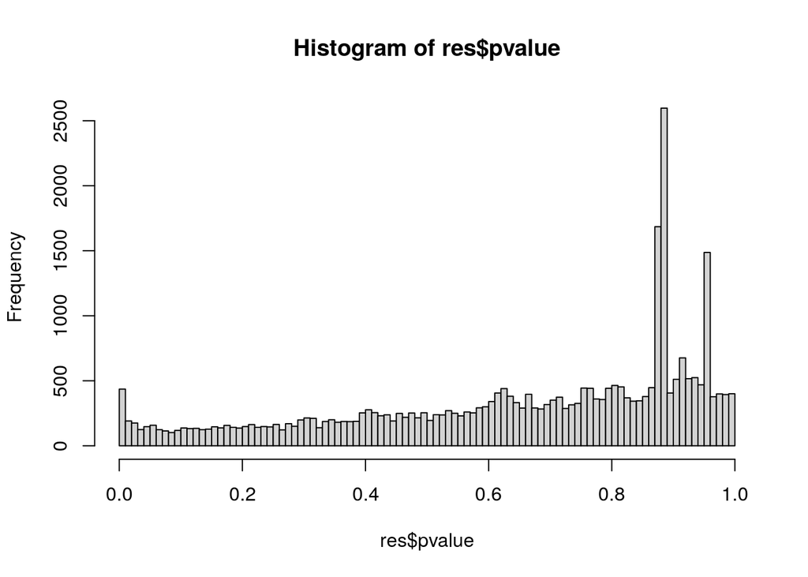

```r
hist(res$pvalue,breaks=seq(0,1,.01))
```

Note that there are few genes with differential expression between Tissues at the FDR level of 10%. Nonetheless, there are two ways to be more strict about which set of genes are considered significant:

- lower the false discovery rate threshold (the threshold on padj in the results table)
- raise the log2 fold change threshold from 0 using the lfcThreshold argument of results If we lower the false discovery rate threshold, we should also tell this value to `results()`, so that the function will use an alternative threshold for the optimal independent filtering step:

```r
res.05 <- results(ds_se, name="Tissue_ZE_vs_FMG", alpha = 0.05)
table(res.05$padj < 0.05)
```

[output not shown]

If we want to raise the log2 fold change threshold, so that we test for genes that show more substantial changes between tissues, we simply supply a value on the log2 scale. For example, by specifying lfcThreshold = 1, we test for genes that show significant effects between tissues on gene counts more than doubling or less than halving, because `2^1 = 2`.

```r
resLFC1 <- results(ds_se, name="Tissue_ZE_vs_FMG", lfcThreshold = 1)
summary(resLFC1)
```

```
##
## out of 31884 with nonzero total read count
## adjusted p-value < 0.1
## LFC > 1.00 (up)    : 46, 0.14%
## LFC < -1.00 (down) : 64, 0.2%
## outliers [1]       : 1, 0.0031%
## low counts [2]     : 28566, 90%
## (mean count < 5)
## [1] see 'cooksCutoff' argument of ?results
## [2] see 'independentFiltering' argument of ?results
```

```r
table(resLFC1$padj < 0.1)
```

```
##
## FALSE  TRUE
##  3207   110
```

Following Schurch *et al.*, (RNA, 2016) recommandations, we would have for 3 replicates per conditions:

```r
resSchurch <- results(ds_se, name="Tissue_ZE_vs_FMG", lfcThreshold = 0.5, alpha = 0.01)
summary(resSchurch)
```

```
##
## out of 31884 with nonzero total read count
## adjusted p-value < 0.01
## LFC > 0.50 (up)    : 19, 0.06%
## LFC < -0.50 (down) : 41, 0.13%
## outliers [1]       : 1, 0.0031%
## low counts [2]     : 28566, 90%
## (mean count < 5)
## [1] see 'cooksCutoff' argument of ?results
## [2] see 'independentFiltering' argument of ?results
```

Sometimes a subset of the p values in res will be NA (“not available”). This is DESeq’s way of reporting that all counts for this gene were zero, and hence no test was applied. In addition, p values can be assigned `NA` if the gene was excluded from analysis because it contained an extreme count outlier. For more information, see the outlier detection section of the `DESeq2` vignette.

### 2.1.1 Visualisation

#### 2.1.1.1 Assessment

A volcano plot (the naming is probably obvious) is very useful to check whether the assumption that most genes are not DE holds.

The plot has a representation of density as a color gradient from sparse to dense (gray -> blue -> red -> yellow). Note that the light blue, confusingly shows DE genes.

Here clearly most genes are located at 0,0 (the yellow dot)

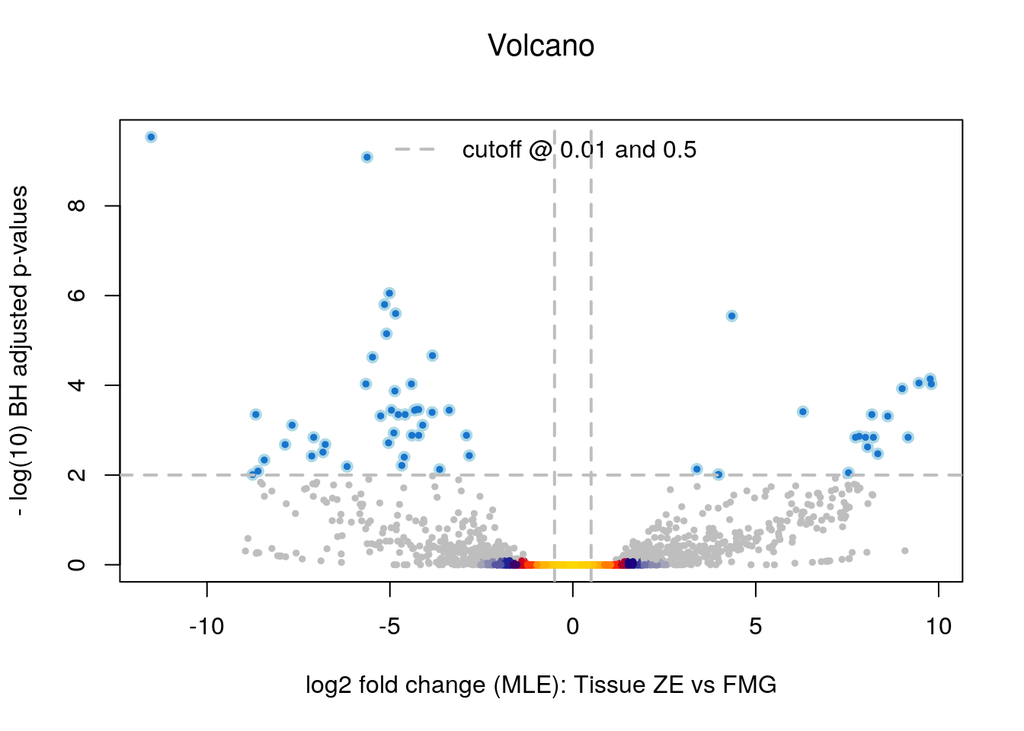

```r
volcanoPlot(resSchurch)
```

#### 2.1.1.2 Individual genes

With DESeq2, there is also an easy way to plot the (normalized, transformed) counts for specific genes, using the plotCounts function:

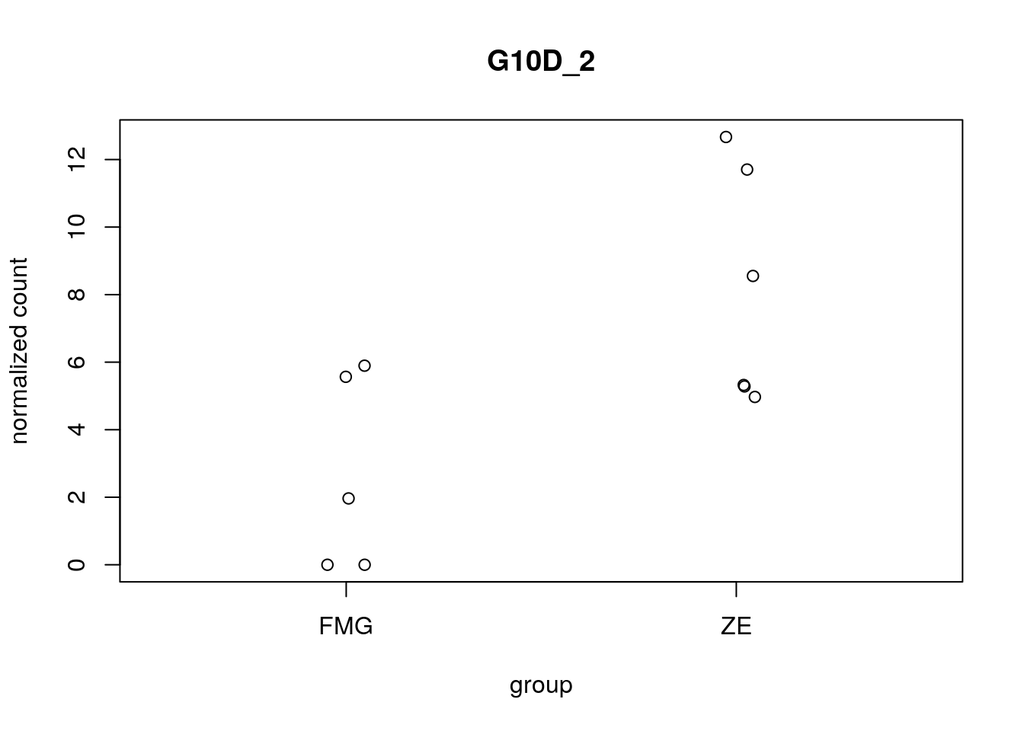

```r
plotCounts(ds_se, gene = "G10D_2", intgroup = "Tissue",
           normalized = TRUE, transform = FALSE)
```

This is actually an insteresting case as G10D_2 is a Long Terminal Repeat (LTR). Fascinating to see that they are deregulated in the ZE, as compared to the FMG, probably related to the modified epigenome of the embryo.

## 2.2 Performing differential expression testing with edgeR

Next we will show how to perform differential expression analysis with edgeR. Recall that we have a *DGEList* `dge`, containing all the necessary information:

```r
names(dge)
```

```
## [1] "counts"  "samples" "genes"   "offset"
```

We first define a design matrix, using the same formula syntax as for *DESeq2* above.

```r
design <- model.matrix(~ Tissue * Time, data = dge$samples)
```

While `DESeq2` performs independent filtering of lowly expressed genes internally, this is done by the user before applying edgeR. Here, we filter out lowly expressed genes using the filterByExpr() function, and then estimate the dispersion for each gene. Note that it is important that we specify the design in the dispersion calculation. Afterwards, we plot the estimated dispersions.

First, we perform the independent filtering (based on the model, filter the genes that have no power to be detected as differentially expressed. This aims at removing genes so lowly expressed that they represent “noise”)

```r
keep <- edgeR::filterByExpr(dge, design)
table(keep)
```

```
## keep
## FALSE  TRUE
## 63973  2387
```

```r
dge <- dge[keep, ]
```

Then we estimate the dispersion

```r
dge <- edgeR::estimateDisp(dge, design)
```

And we can take a look at the dispersion estimation (dispersion == biological coefficient of variation)

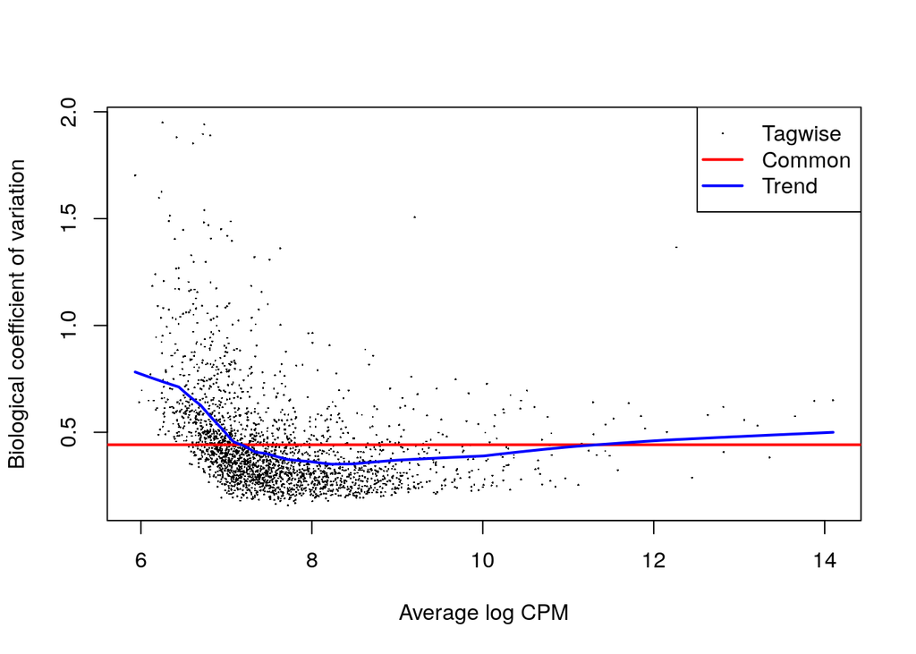

```r
edgeR::plotBCV(dge)
```

Finally, we fit the generalized linear model and perform the test. In the `glmQLFTest` function, we indicate which coefficient (which column in the design matrix) that we would like to test for. It is possible to test more general contrasts as well, and the user guide contains many examples on how to do this. The topTags function extracts the top-ranked genes. You can indicate the adjusted p-value cutoff, and/or the number of genes to keep.

```r
fit <- edgeR::glmQLFit(dge, design)
```

What is the design?

```r
design
```

```
##            (Intercept) TissueZE TimeB8 TissueZE:TimeB8
## P11562_110           1        0      0               0
## P11562_111           1        1      0               0
## P11562_113           1        1      0               0
## P11562_114           1        0      0               0
## P11562_115           1        1      0               0
## P11562_134           1        0      1               0
## P11562_135           1        1      1               1
## P11562_136           1        0      1               0
## P11562_137           1        1      1               1
## P11562_138           1        0      1               0
## P11562_139           1        1      1               1
## attr(,"assign")
## [1] 0 1 2 3
## attr(,"contrasts")
## attr(,"contrasts")$Tissue
## [1] "contr.treatment"
##
## attr(,"contrasts")$Time
## [1] "contr.treatment"
```

```r
# To test as we did for DESeq2, we select the second column
qlf <- edgeR::glmQLFTest(fit, coef = 2)
```

Finally looking at the results

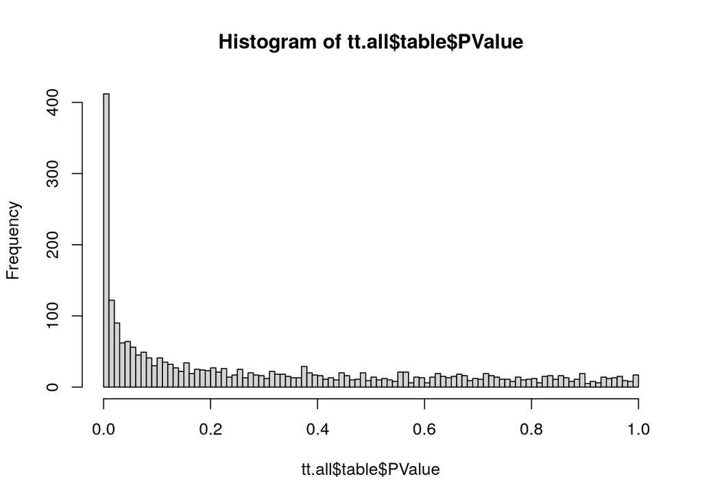

```r
tt.all <- edgeR::topTags(qlf, n = nrow(dge), sort.by = "none") # all genes
hist(tt.all$table$PValue,breaks=seq(0,1,.01))
```

```r
tt <- edgeR::topTags(qlf, n = nrow(dge), p.value = 0.01) # genes with adj.p<0.01
tt10 <- edgeR::topTags(qlf) # just the top 10 by default
tt10
```

```
## Coefficient:  TissueZE
##                           gene.id      logFC    logCPM         F       PValue
## MA_177060g0010     MA_177060g0010   4.454312  8.165194 133.58144 4.233476e-08
## MA_74039g0010       MA_74039g0010  -5.419775 10.237061 105.62378 1.640146e-07
## MA_73656g0010       MA_73656g0010   7.646164  7.359570 100.43994 4.404519e-07
## MA_10437145g0010 MA_10437145g0010   7.814243  7.111758  91.25871 7.285176e-07
## MA_10436440g0030 MA_10436440g0030   4.098621  8.737947  74.11062 1.190740e-06
## MA_124460g0010     MA_124460g0010  -8.638246  9.452628  70.84062 1.523270e-06
## MA_16307g0010       MA_16307g0010 -11.236386  8.174892 131.52939 1.544971e-06
## MA_86195g0010       MA_86195g0010   9.258936  7.461482  72.54672 2.379090e-06
## MA_99845g0010       MA_99845g0010   3.517324  8.416774  61.28022 3.324528e-06
## MA_94115g0010       MA_94115g0010   8.255414  7.399440  88.45112 3.537409e-06
##                           FDR
## MA_177060g0010   0.0001010531
## MA_74039g0010    0.0001957514
## MA_73656g0010    0.0003504529
## MA_10437145g0010 0.0004347429
## MA_10436440g0030 0.0005268352
## MA_124460g0010   0.0005268352
## MA_16307g0010    0.0005268352
## MA_86195g0010    0.0007098610
## MA_99845g0010    0.0008443796
## MA_94115g0010    0.0008443796
```

The columns in the edgeR result data frame are similar to the ones output by DESeq2. edgeR represents the overall expression level on the log-CPM scale rather than on the normalized count scale that DESeq2 uses. The F column contains the test statistic, and the FDR column contains the Benjamini-Hochberg adjusted p-values.

We can compare the sets of significantly differentially expressed genes to see how the results from the two packages overlap:

```r
shared <- intersect(rownames(res), tt.all$table$gene.id)
table(DESeq2 = res$padj[match(shared, rownames(res))] < 0.1,
      edgeR = tt.all$table$FDR[match(shared, tt.all$table$gene.id)] < 0.1)
```

```
##        edgeR
## DESeq2  FALSE TRUE
##   FALSE  1802  494
##   TRUE      0   91
```

We can do the same visually

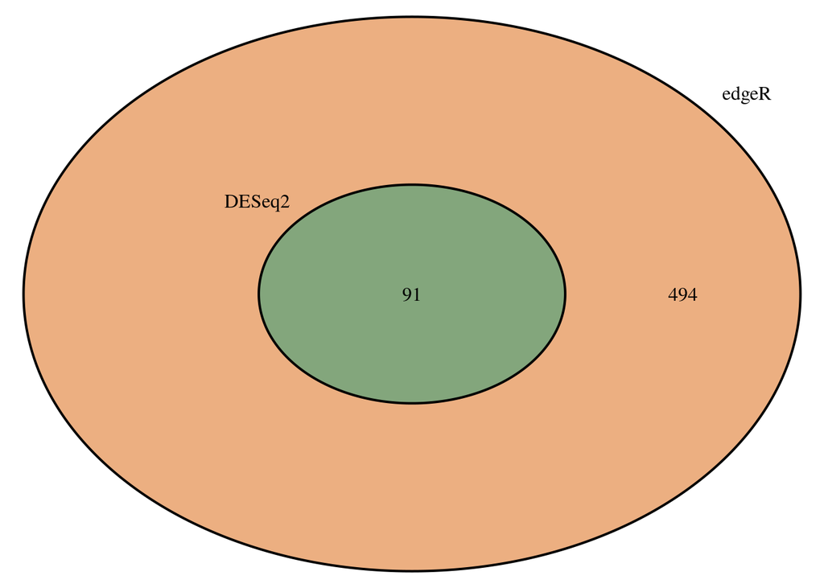

```r
grid.newpage()
d.sel <- match(shared, rownames(res))
e.sel <- match(shared, tt.all$table$gene.id)
grid.draw(venn.diagram(list(DESeq2 = rownames(res)[d.sel][res$padj[d.sel] < 0.1 & !is.na(res$padj[d.sel])],
                            edgeR = tt.all$table$gene.id[e.sel][tt.all$table$FDR[e.sel] < 0.1 & !is.na(tt.all$table$FDR[e.sel])]),
                       NULL,fill=pal[1:2]))
```

We can also compare the two result lists by the ranks:

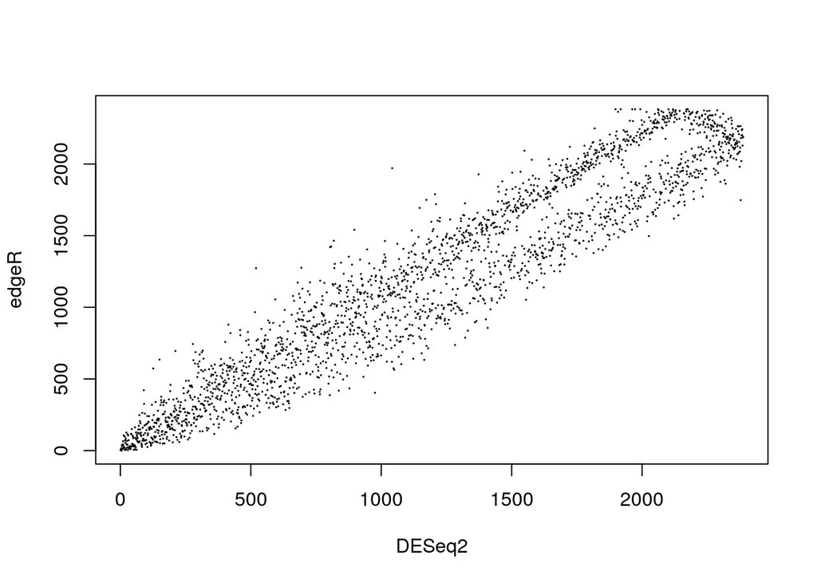

```r
plot(rank(res$pvalue[match(shared, rownames(res))]),
     rank(tt.all$table$PValue[match(shared, tt.all$table$gene.id)]),
     cex = 0.1, xlab = "DESeq2", ylab = "edgeR")
```

```r
treatres <- edgeR::glmTreat(fit, coef = ncol(design), lfc = 1)
tt.treat <- edgeR::topTags(treatres, n = nrow(dge), sort.by = "none")
```

## 2.3 Multiple testing

In high-throughput biology, we are careful to not use the p values directly as evidence against the null, but to correct for multiple testing. What would happen if we were to simply threshold the p values at a low value, say 0.05?

```r
sum(res$pvalue < 0.05, na.rm = TRUE)
```

```
## [1] 1074
```

and that many genes not NA

```r
sum(!is.na(res$pvalue))
```

```
## [1] 31883
```

Now, assume for a moment that the null hypothesis is true for all genes, i.e., no gene is affected in either Tissue. Suppose we are interesting in a significance level of 0.05. Then, by the definition of the p value, we expect up to 5% of the genes to have a p value below 0.05. This amounts to

```r
round(sum(!is.na(res$pvalue)) * 0.05)
```

```
## [1] 1594
```

If we just considered the list of genes with a p value below 0.05 as differentially expressed, this list should therefore be expected to contain many false positives:

```r
round(sum(!is.na(res$pvalue))*0.05 / sum(res$pvalue < 0.05, na.rm = TRUE), 2)
```

```
## [1] 1.48
```

DESeq2 and edgeR use the Benjamini-Hochberg (BH) adjustment (Benjamini and Hochberg 1995) as implemented in the base R p.adjust function; in brief, this method calculates for each gene an adjusted p value that answers the following question: if one called significant all genes with an adjusted p value less than or equal to this gene’s adjusted p value threshold, what would be the fraction of false positives (the false discovery rate, FDR) among them, in the sense of the calculation outlined above? These values, called the BH-adjusted p values, are given in the column padj of the res object from DESeq2, and in the FDR column in the TopTags object from edgeR.

The FDR is a useful statistic for many high-throughput experiments, as we are often interested in reporting or focusing on a set of interesting genes, and we would like to put an upper bound on the percent of false positives in this set.

Hence, if we consider a fraction of 10% false positives acceptable, we can consider all genes with an adjusted p value below 10% = 0.1 as significant. How many such genes are there?

```r
sum(res$padj < 0.1, na.rm = TRUE)
```

```
## [1] 123
```

# 3 Plotting results

## 3.1 MA plot with DESeq2

An MA-plot (Dudoit et al. 2002) provides a useful overview for an experiment with a two-group comparison (Figure below). The log2 fold change for a particular comparison is plotted on the y-axis and the average of the counts normalized by size factor is shown on the x-axis (“M” for minus, because a log ratio is equal to log minus log, and “A” for average). Each gene is represented with a dot. Genes with an adjusted p value below a threshold (here 0.1, the default with DESeq2) are shown in blue.

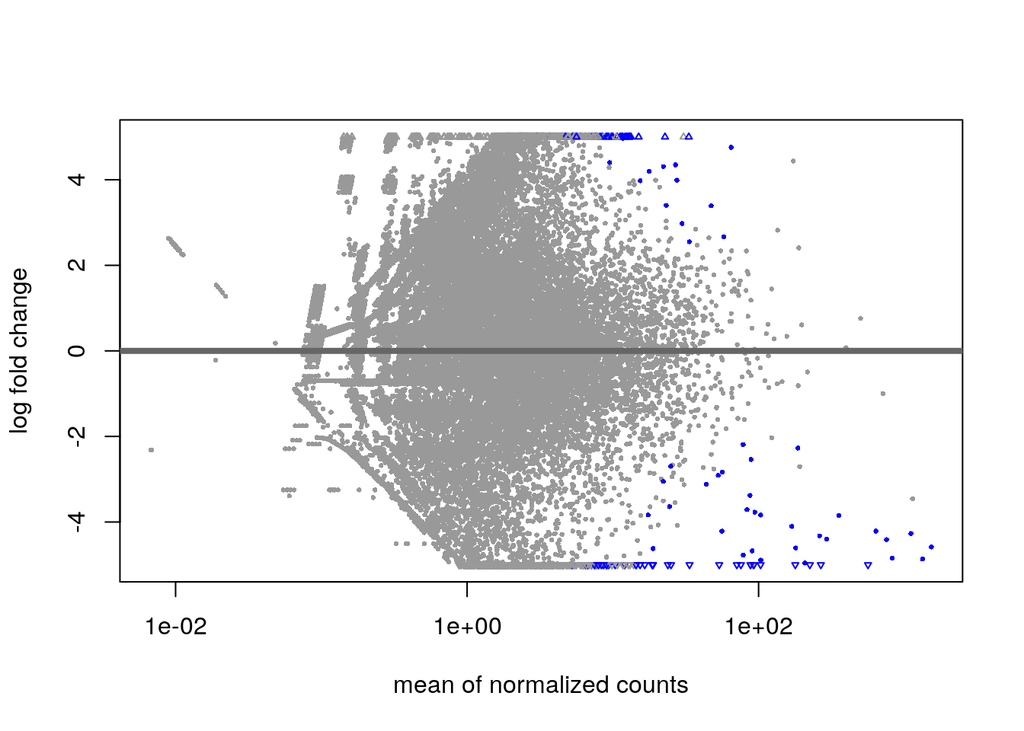

```r
DESeq2::plotMA(res, ylim = c(-5, 5))
```

## 3.2 MA / Smear plot with edgeR

In edgeR, the MA plot is obtained via the plotSmear function. The genes below the adjusted p value threshold are shown in red.

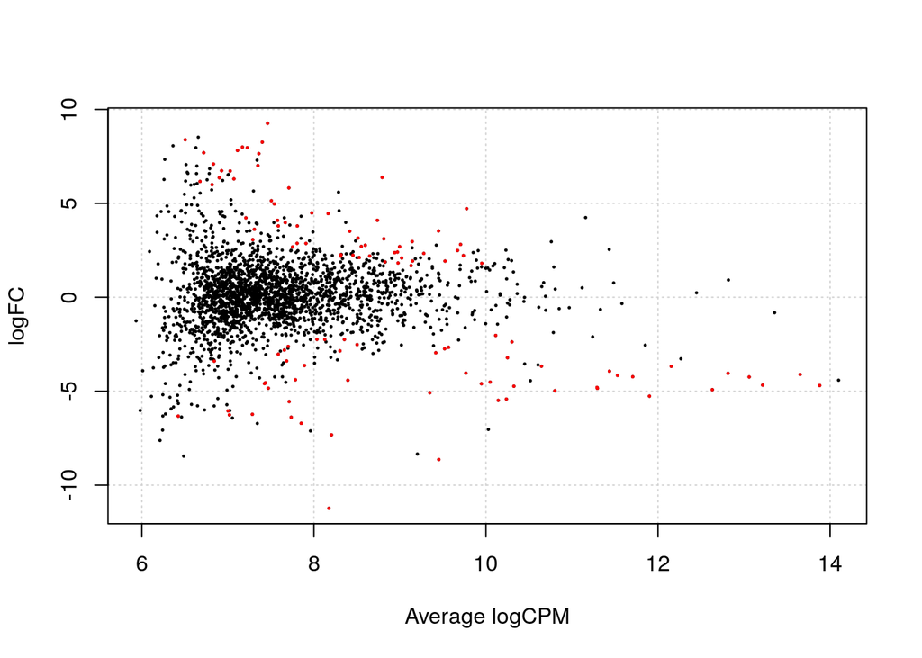

```r
edgeR::plotSmear(qlf, de.tags = tt$table$gene.id)
```

## 3.3 Heatmap of the most significant genes

Another way of representing the results of a differential expression analysis is to construct a heatmap of the top differentially expressed genes. Here, we would expect the contrasted sample groups to cluster separately. A heatmap is a “color coded expression matrix”, where the rows and columns are clustered using hierarchical clustering. Typically, it should not be applied to counts, but works better with transformed values. Here we show how it can be applied to the variance-stabilized values generated above. We choose the top 30 differentially expressed genes. There are many functions in R that can generate heatmaps, here we show the one from the pheatmap package.

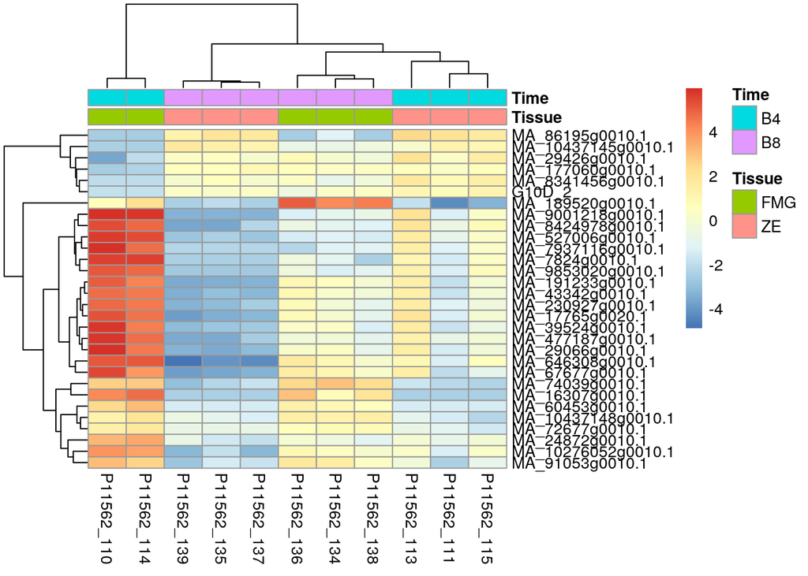

```r
mat <- assay(vsd)[head(order(res$padj), 30), ]
mat <- mat - rowMeans(mat)
df <- as.data.frame(colData(vsd)[, c("Tissue", "Time")])
pheatmap(mat, annotation_col = df)
```

# 5 References

Anders, Simon, Alejandro Reyes, and Wolfgang Huber. 2012. “Detecting Differential Usage of Exons from RNA-seq Data.” Genome Res. 22 (10): 2008–17.

Benjamini, Yoav, and Yosef Hochberg. 1995. “Controlling the False Discovery Rate: A Practical and Powerful Approach to Multiple Testing.” Journal of the Royal Statistical Society. Series B (Methodological) 57 (1): 289–300. http://www.jstor.org/stable/2346101.

Bray, Nicolas L, Harold Pimentel, Páll Melsted, and Lior Pachter. 2016. “Near-Optimal RNA-Seq Quantification.” Nat. Biotechnol.

Dobin, Alexander, Carrie A. Davis, Felix Schlesinger, Jorg Drenkow, Chris Zaleski, Sonali Jha, Philippe Batut, Mark Chaisson, and Thomas R. Gingeras. 2013. “STAR: ultrafast universal RNA-seq aligner.” Bioinformatics 29 (1). Oxford University Press: 15–21. https://doi.org/10.1093/bioinformatics/bts635.

Dudoit, Sandrine, Yee H. Yang, Matthew J. Callow, and Terence P. Speed. 2002. “Statistical methods for identifying differentially expressed genes in replicated cDNA microarray experiments.” In Statistica Sinica, 111–39. http://citeseerx.ist.psu.edu/viewdoc/summary?doi=10.1.1.117.9702.

Hardcastle, Thomas, and Krystyna Kelly. 2010. “baySeq: Empirical Bayesian methods for identifying differential expression in sequence count data.” BMC Bioinformatics 11 (1): 422+. https://doi.org/10.1186/1471-2105-11-422.

Himes, Blanca E., Xiaofeng Jiang, Peter Wagner, Ruoxi Hu, Qiyu Wang, Barbara Klanderman, Reid M. Whitaker, et al. 2014. “RNA-Seq transcriptome profiling identifies CRISPLD2 as a glucocorticoid responsive gene that modulates cytokine function in airway smooth muscle cells.” PloS One 9 (6). https://doi.org/10.1371/journal.pone.0099625.

Law, Charity W., Yunshun Chen, Wei Shi, and Gordon K. Smyth. 2014. “Voom: precision weights unlock linear model analysis tools for RNA-seq read counts.” Genome Biology 15 (2). BioMed Central Ltd: R29+. https://doi.org/10.1186/gb-2014-15-2-r29.

Leng, N., J. A. Dawson, J. A. Thomson, V. Ruotti, A. I. Rissman, B. M. G. Smits, J. D. Haag, M. N. Gould, R. M. Stewart, and C. Kendziorski. 2013. “EBSeq: an empirical Bayes hierarchical model for inference in RNA-seq experiments.” Bioinformatics 29 (8). Oxford University Press: 1035–43. https://doi.org/10.1093/bioinformatics/btt087.

Li, Bo, and Colin N. Dewey. 2011. “RSEM: accurate transcript quantification from RNA-Seq data with or without a reference genome.” BMC Bioinformatics 12: 323+. https://doi.org/10.1186/1471-2105-12-3231.

Liao, Y., G. K. Smyth, and W. Shi. 2014. “featureCounts: an efficient general purpose program for assigning sequence reads to genomic features.” Bioinformatics 30 (7). Oxford University Press: 923–30. https://doi.org/10.1093/bioinformatics/btt656.

Love, Michael I., Simon Anders, Vladislav Kim, and Wolfgang Huber. 2015. “RNA-Seq Workflow: Gene-Level Exploratory Analysis and Differential Expression.” F1000Research, October. https://doi.org/10.12688/f1000research.7035.1.

Love, Michael I., Wolfgang Huber, and Simon Anders. 2014. “Moderated estimation of fold change and dispersion for RNA-seq data with DESeq2.” Genome Biology 15 (12). BioMed Central Ltd: 550+. https://doi.org/10.1186/s13059-014-0550-8.

Patro, Rob, Geet Duggal, Michael I Love, Rafael A Irizarry, and Carl Kingsford. 2017. “Salmon Provides Fast and Bias-Aware Quantification of Transcript Expression.” Nat. Methods.

Patro, Rob, Stephen M. Mount, and Carl Kingsford. 2014. “Sailfish enables alignment-free isoform quantification from RNA-seq reads using lightweight algorithms.” Nature Biotechnology 32: 462–64. https://doi.org/10.1038/nbt.2862.

Robinson, M. D., D. J. McCarthy, and G. K. Smyth. 2009. “edgeR: a Bioconductor package for differential expression analysis of digital gene expression data.” Bioinformatics 26 (1). Oxford University Press: 139–40. https://doi.org/10.1093/bioinformatics/btp616.

Soneson, Charlotte, Michael I. Love, and Mark Robinson. 2015. “Differential analyses for RNA-seq: transcript-level estimates improve gene-level inferences.” F1000Research 4 (1521). https://doi.org/10.12688/f1000research.7563.1.

Trapnell, Cole, David G Hendrickson, Martin Sauvageau, Loyal Goff, John L Rinn, and Lior Pachter. 2013. “Differential Analysis of Gene Regulation at Transcript Resolution with RNA-seq.” Nat. Biotechnol. 31 (1): 46–53.

Trapnell, Cole, Brian a Williams, Geo Pertea, Ali Mortazavi, Gordon Kwan, Marijke J van Baren, Steven L Salzberg, Barbara J Wold, and Lior Pachter. 2010. “Transcript Assembly and Quantification by RNA-Seq Reveals Unannotated Transcripts and Isoform Switching During Cell Differentiation.” Nat. Biotechnol. 28 (5): 511–15.

Wu, Hao, Chi Wang, and Zhijin Wu. 2013. “A new shrinkage estimator for dispersion improves differential expression detection in RNA-seq data.” Biostatistics 14 (2). Oxford University Press: 232–43. https://doi.org/10.1093/biostatistics/kxs033.

Zeeberg, Barry R, Joseph Riss, David W Kane, Kimberly J Bussey, Edward Uchio, W Marston Linehan, J Carl Barrett, and John N Weinstein. 2004. “Mistaken Identifiers: Gene Name Errors Can Be Introduced Inadvertently When Using Excel in Bioinformatics.” BMC Bioinformatics 5: 80.

Ziemann, Mark, Yotam Eren, and Assam El-Osta. 2016. “Gene Name Errors Are Widespread in the Scientific Literature.” Genome Biol. 17 (1): 1–3.